# Спрос на рейсы авиакомпании

Вы аналитик российской авиакомпании F9, выполняющей внутренние пассажирские перевозки. Важно понять предпочтения пользователей, покупающих билеты на разные направления.

Вам предстоит изучить базу данных и проанализировать спрос пассажиров на рейсы в города, где проходят крупнейшие культурные фестивали.

У вас есть файлы с результатами запросов из предыдущих заданий.

**query_1.csv** — результат первого запроса. В нём содержится такая информация:

- *model* — **модель самолета;
- *flights_amount* — количество рейсов для каждой модели самолетов *model* в сентябре 2018 года.

**query_3.csv** — результат третьего запроса. В нём содержится такая информация:

- *city* — город;
- *average_flights* — среднее количество рейсов, прибывающих в город (*city*) за день в сентябре 2018 года.

  Для этих двух наборов данных нужно:
- импортировать файлы;
- изучить данные в них;
- проверить типы данных на корректность;
- выбрать топ-10 городов по количеству рейсов;
- построить графики: модели самолётов и количество рейсов, города и количество рейсов, топ-10 городов и количество рейсов;
- сделать выводы по каждому из графиков, пояснить результат.

## 1. Аналитика

**Все импорты**

```python
import numpy as np
import pandas as pd
import matplotlib.pyplot as plt
```

### 1.1. Импорт файлов

```python
df1 = pd.read_csv(r'C:\Users\Алекс\Downloads\query_1.csv', encoding="utf-8")
df3 = pd.read_csv(r'C:\Users\Алекс\Downloads\query_3.csv', encoding="utf-8")
```

### 1.2. Изучение данных и проверка типов

**Query_1**

```python
df1
```

|  | model | flights_amount |
| --- | --- | --- |
| 0 | Airbus A319-100 | 607 |
| 1 | Airbus A321-200 | 960 |
| 2 | Boeing 737-300 | 630 |
| 3 | Boeing 767-300 | 600 |
| 4 | Boeing 777-300 | 300 |
| 5 | Bombardier CRJ-200 | 4446 |
| 6 | Cessna 208 Caravan | 4557 |
| 7 | Sukhoi SuperJet-100 | 4185 |

```python
df1.info()
```

```
<class 'pandas.core.frame.DataFrame'>
RangeIndex: 8 entries, 0 to 7
Data columns (total 2 columns):
 #   Column          Non-Null Count  Dtype
---  ------          --------------  -----
 0   model           8 non-null      object
 1   flights_amount  8 non-null      int64
dtypes: int64(1), object(1)
memory usage: 256.0+ bytes
```

ВЫВОД: данные корректны и типы в них тоже

**Query_3**

```python
df3.head(5)
```

|  | city | average_flights |
| --- | --- | --- |
| 0 | Абакан | 3.870968 |
| 1 | Анадырь | 1.000000 |
| 2 | Анапа | 2.161290 |
| 3 | Архангельск | 5.354839 |
| 4 | Астрахань | 2.451613 |

```python
df3.info()
```

```
<class 'pandas.core.frame.DataFrame'>
RangeIndex: 101 entries, 0 to 100
Data columns (total 2 columns):
 #   Column           Non-Null Count  Dtype
---  ------           --------------  -----
 0   city             101 non-null    object
 1   average_flights  101 non-null    float64
dtypes: float64(1), object(1)
memory usage: 1.7+ KB
```

ВЫВОД: данные корректны и типы в них тоже

### 1.3. Выбор топ-10 городов по количеству рейсов

```python
df3.sort_values('average_flights', ascending = False).head(10)
```

|  | city | average_flights |
| --- | --- | --- |
| 43 | Москва | 129.774194 |
| 70 | Санкт-Петербург | 31.161290 |
| 54 | Новосибирск | 17.322581 |
| 33 | Красноярск | 11.580645 |
| 20 | Екатеринбург | 11.322581 |
| 67 | Ростов-на-Дону | 10.193548 |
| 63 | Пермь | 10.129032 |
| 10 | Брянск | 10.000000 |
| 74 | Сочи | 9.612903 |
| 84 | Ульяновск | 9.580645 |

ВЫВОД: список из тор 10 городов примерно соответствует списку крупных городов РФ, что не удивительно! а такие города, как Сочи, Брянск, Ульяновск являются достаточно крупными областными и культурными центрами в центральной и южной России.

### 1.4. Построение графиков: модели самолётов и количество рейсов, города и количество рейсов, топ-10 городов и количество рейсов и выводы

**Модель самолётов и количество рейсов**

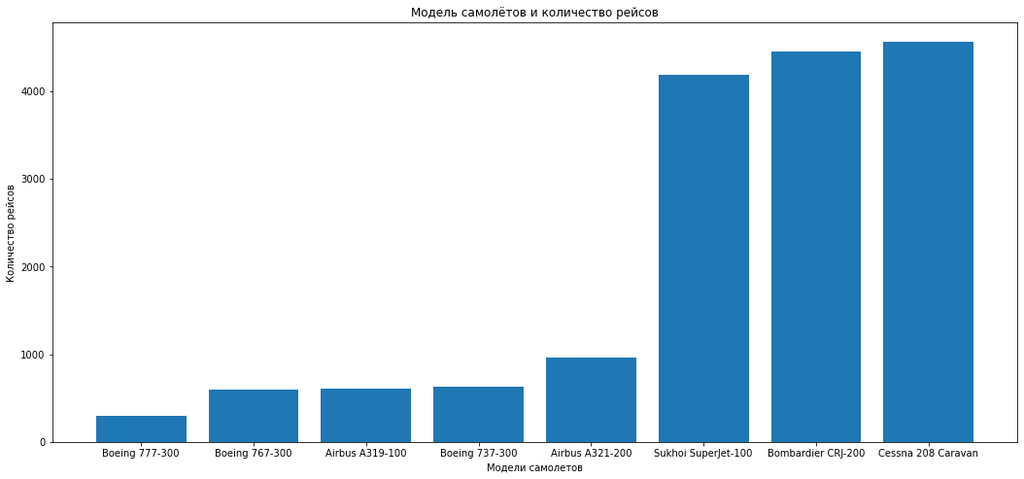

```python
fig = plt.figure()
ax = fig.add_axes([0,0,2.3,1.5])
model = df1.sort_values('flights_amount', ascending = True)['model']
flights_amount = df1.sort_values('flights_amount', ascending = True)['flights_amount']
ax.bar(model, flights_amount)
ax.set_ylabel('Количество рейсов')
ax.set_xlabel('Модели самолетов')
ax.set_title('Модель самолётов и количество рейсов')
plt.show()
```

ВЫВОД: топ 3 модели самолетов, совершившие больше всего рейсов Bombardier CRJ-200, Cessna 208 Caravan, Sukhoi SuperJet-100; эти самолеты не относятся к машинам европейских и американских авиаконструкторов-гигантов, полагаю, самолеты из тор 3 моделей стоят дешевле, доступнее, поэтому их и больше в "арсенале" авиакомпании F9.

**Города и количество рейсов**

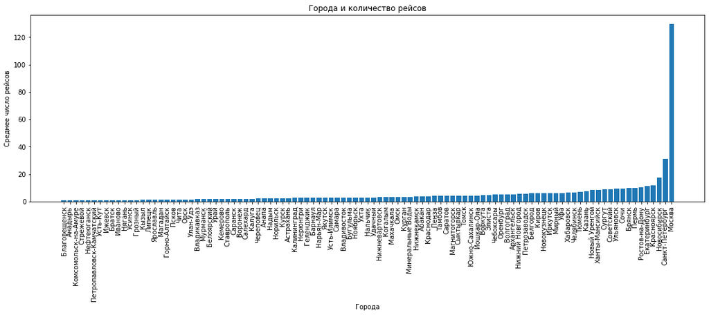

```python
fig = plt.figure()
ax = fig.add_axes([0,0,2.4,1])
city = df3.sort_values('average_flights', ascending = True)['city']
average_flights = df3.sort_values('average_flights', ascending = True)['average_flights']
ax.bar(city, average_flights)
ax.set_ylabel('Среднее число рейсов')
ax.set_xlabel('Города')
plt.xticks(rotation=90)
ax.set_title('Города и количество рейсов')
plt.show()
```

ВЫВОД: смотреть общий вывод

**Топ-10 городов и количество рейсов**

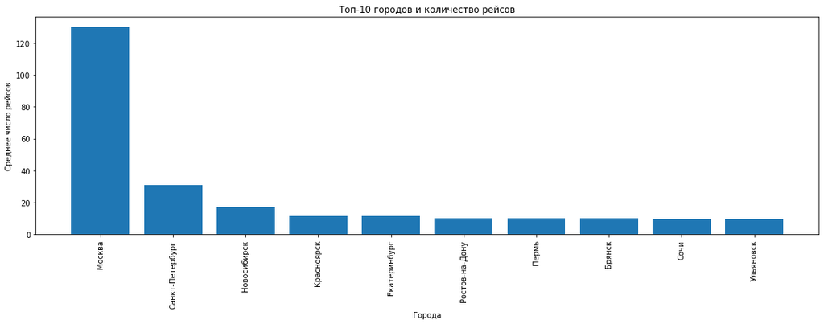

```python
fig = plt.figure()
ax = fig.add_axes([0,0,2.4,1])
city = df3.sort_values('average_flights', ascending = False).head(10)['city']
average_flights = df3.sort_values('average_flights', ascending = False).head(10)['average_flights']
ax.bar(city, average_flights)
ax.set_ylabel('Среднее число рейсов')
ax.set_xlabel('Города')
plt.xticks(rotation=90)
ax.set_title('Топ-10 городов и количество рейсов')
plt.show()
```

ВЫВОД: смотреть общий вывод

### 1.5. Общий вывод

ЦИТАТА ИЗ ЗАДАНИЯ...

"Вы аналитик российской авиакомпании F9, выполняющей внутренние пассажирские перевозки. Важно понять предпочтения пользователей, покупающих билеты на разные направления.

Вам предстоит изучить базу данных и проанализировать спрос пассажиров на рейсы в города, где проходят крупнейшие культурные фестивали.

У вас есть файлы с результатами запросов из предыдущих заданий."

*"Косяк":* он заключается в том, что нет датасета, где мы можем посчитать ТОП городов, в которых вообще проводятся культурные фестивали. У нас есть данные только о моделях самолетов, которые имеются "в арсенале" авиакомпании F9 и данные о среднем количестве полетов за период в тот или иной город. "Проанализировать спрос пассажиров на рейсы в города, где проходят крупнейшие культурные фестивали"

*Какие выводы мы можем сделать:*

1) "В арсенале" авиакомпании F9 либо больше самолетов моделей Bombardier CRJ-200, Cessna 208 Caravan, Sukhoi SuperJet-100 (по причине доступности, стоимости и т.д.), либо данные самолеты просто чаще летают или на более близкие расстояния по разным городам (то есть, Boeing и Airbus могут использоваться для таких рейсов, как СПБ-Владивосток, пока Bombardier CRJ-200, условно, 4 раза пролетит расстояние от Москвы до Брянска);

2) Чем крупнее город, тем больше, в среднем, в него идет рейсов (да, здесь есть ремарочка с таким городом, как Сочи, где население 364к, но рейсов больше, чем в Самару, так как это "безальтернативный" курорт и южный культурный центр для всех жителей РФ).

Итог: спрос в крупные города и культурные центры РФ больше, чем в другие города необъятной! Пассажиры предпочитают летать на самолете модели Cessna 208 Caravan (???).

*Как бы я сделал "дизайн" исследования:*

1) Попросил бы у специалиста по ETL (или бы сам из базы выгрузил в .csv) датасет с таблицей festivals

2) Посчитал бы количество фестивалей в "фестивальных" городах, заджойнил бы это с query_3, сформировал бы гипотезы, посчитал бы корреляцию и подтвердил/опровергнул гипотезу о наличии зависимости между величиной спроса и средним количеством фестивалей в городах + мог бы визуализировать и построить кривые спроса и среднего количества фестивалей

Итог: получил бы вывод о наличии зависимости, имеющий графические и статистические подтверждения

*Ремарка:*

Не исключаю, что я мог в корне не понять задание и то, что от меня требуется, и в таблице query_3 при формировании датасета и выгрузке был уже учтен фактор "влияния" фестивалей и "культурности" города на среднее количество рейсов, но тогда, будьте добры, упомяните это в задании... (это больше риторика в сторону разрабов программы)

## Чек-лист проверки

- [x] Jupyter Notebook открыт
- [ ] Весь код выполняется без ошибок
- [ ] Ячейки с кодом расположены в порядке исполнения
- [ ] Файлы изучены
- [ ] Типы данных проверены на корректность
- [ ] Выбран топ-10 городов по количеству рейсов
- [ ] Построен график «Модели самолётов и количество рейсов»
- [ ] Построен график «Города и количество рейсов»
- [ ] Построен график «Топ-10 городов и количество рейсов»
- [ ] На каждом этапе написаны выводы
- [ ] Написан общий вывод